# Home Work 2

Diletta Abbonato, Liwam Andom

```r
library(corrplot)
library(igraph)
library(visNetwork)
library(data.table)
require(tseries, quietly = TRUE)
```

#### Select a sensible portfolio of stocks and take data from January 1, 2003 through January 1, 2008, before the onset of the “Financial crisis”. Build the data matrix $X=[x~{tj}]~{t,j}$

We took a portflolio of stocks in the S&P500 index from wikipedia. We cleaned our data to assure consistency. The stocks retrieved from wikipedia are still active therefore we check if the stocks in our data were active starting from January of 2003.

```r
table_1=read.csv("table-1.csv")
attach(table_1)
#Keep only companies active since Jan 2003
table_1 <- table_1[,-c(3,5,6,8,9)]
names(table_1) <- c('symbol', 'security', 'gics', 'DATE')
DATE <- as.Date(table_1$DATE, '%Y-%m-%d')
table_1 <- table_1[(DATE <= "2003-01-01"),]
```

We randomly picked $3$ stocks from each GICS sector. After cleaning the GICS sector ‘Real Estate’ only had two stocks therefore our total number of stocks is $32$.

```r
X=read.csv("X.csv")
X=X[,-1]
attach(X)

Communication_Services =subset(X, gics== 'Communication Services', select = 'symbol')
Consumer_Discretionary =subset(X, gics== 'Consumer Discretionary', select = 'symbol')
Energy =subset(X, gics== 'Energy', select = 'symbol')
Financials =subset(X, gics== 'Financials', select = 'symbol')
Consumer_Staples =subset(X, gics== 'Consumer Staples', select = 'symbol')
Health_Care =subset(X, gics== 'Health Care', select = 'symbol')
Industrials =subset(X, gics== 'Industrials', select = 'symbol')
Information_Technology =subset(X, gics== 'Information Technology', select = 'symbol')
Materials =subset(X, gics== 'Materials', select = 'symbol')
Utilities =subset(X, gics== 'Utilities', select = 'symbol')
Real_Estate =subset(X, gics== 'Real Estate', select = 'symbol')

#From each partion of GICS, randomly pick 3 companies
gics_level=c(Communication_Services,Consumer_Discretionary,Energy,Financials,Consumer_Staples,Health_Care,Industrials,Information_Technology,Materials,Utilities)
g_ics=c()

set.seed(1234)
for (g in gics_level) {

  g_ics = c(g_ics, sample(g, size=3, replace=F))
}
g_ics = c(g_ics,68,130)

X=X[g_ics,]
write.table( X, file="x2.csv", append=F, sep=",",
             col.names=colnames(X))

#XX is a matrix of the randomly picked companies.
XX = read.csv('x2.csv',stringsAsFactors=FALSE)
```

We make a function to calculate the logarithm of the closing prices. With this function we build a matrix $X=[x~{tj}]~{t,j}$

```r
function_1=function(i){
  log(b$Close[[i]]/b$Close[[i-1]])
}
```

We retrieved the financial historical data for each stock using ‘get.hist.quote’.

```r
#stock_names contains list of stock names of the randomly picked companies
stock_names = XX$symbol
#get historical data for each stock from 2003-01-01 to 2008-01-01 using get.hist.quote() from Yahoo, calculate closing price and save in a matrix vv
temp_sym = stock_names[1]
temp <- suppressWarnings( get.hist.quote(instrument=temp_sym, start="2003-01-01", end="2008-01-01", quote= c("Open","Close"), provider="yahoo", drop=TRUE) )
```

```
## time series starts 2003-01-02
## time series ends   2007-12-31
```

```r
vv =matrix(data=NA,ncol=length(temp)/2, nrow=length(XX[,1]))
for (j in 1:length(XX[,1])){
  b <- suppressWarnings( get.hist.quote(instrument=stock_names[j], start="2003-01-01", end="2008-01-01", quote= c("Open","Close"), provider="yahoo", drop=TRUE) )
  for (i in 2:length(b$Close))  {
    vv[j,i-1] = function_1(i)
  }
}
```

[output not shown]

[output cut: 9 more lines]

[output not shown]

```r
#transpose our matrix: features = stocks
stock_data = t(vv)
colnames(stock_data) = stock_names
```

Our task is verify the hypothesis that stocks from the same GICS sector tend to interact more with eachother. To do that, first we calculate the correlation of our sample data.

```r
#calculate correlation
s <- stock_data[1:1257,]
correlation = cor(s)
```

We bootstraped our sample data 1000 times and calculated pearson correlation coe???cient to get confidence interval.

```r
#Bootstraping 1000 times
B = 1000
#length of our value(number of closing prices for a stock)
n = length(s[,1])
bootstrap_step = function(){
  #Sample/Pick one trading day at random n times with replacement
  idx = sample(n, replace = T)
  bsamp = s[idx,]
  #calculate correlation for our sampled data
  c_bsamp = cor(bsamp)
  #Perform confidence test for the bootstrap sample
  btheta = sqrt(n) * max(abs(c_bsamp - correlation))
  return(btheta)
}

#b_sample is a list that contains B confidence test of our correlation
b_sample = replicate(B, bootstrap_step())
```

We choose $alpha = 0.05$

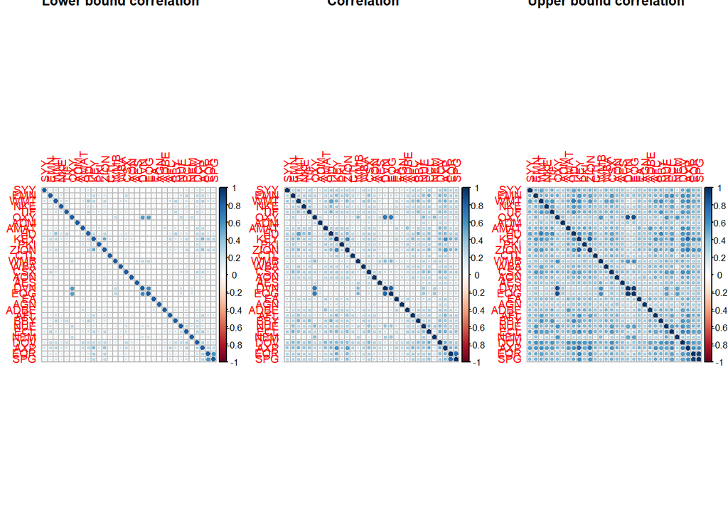

```r
#Calculate t for 95% confidence
t_alpha = quantile(b_sample, 0.95)

#calculate upper bound and lower bound of our correlation
conf_int_alpha_low = correlation - t_alpha/sqrt(n)
conf_int_alpha_up = correlation + t_alpha/sqrt(n)

#When performing confidence interval some values may be out of the range of [-1,1]
#conf_int_alpha_up_adj contains values with in the range of [-1,1]
conf_int_alpha_up_adj = matrix(NA, dim(conf_int_alpha_up)[1], dim(conf_int_alpha_up)[2])

rownames(conf_int_alpha_up_adj) = rownames(conf_int_alpha_up)
colnames(conf_int_alpha_up_adj) = colnames(conf_int_alpha_up)

#Fix values out of the range of [-1,1]
for (i in 1:dim(conf_int_alpha_up)[1]){
  for (j in 1:dim(conf_int_alpha_up)[2]){
    conf_int_alpha_up_adj[i,j] = min(max(conf_int_alpha_up[i,j], -1), 1)
  }
}

par(mfrow = c(1,3))

#plot correlations
corrplot(conf_int_alpha_low, method = 'circle', main="Lower bound correlation")
corrplot(correlation, method = 'circle', main = "Correlation")
corrplot(conf_int_alpha_up_adj, method = 'circle', main = "Upper bound correlation")
```

## Marginal correlation graph

```r
g <- make_empty_graph(directed = F) +
  vertices(stock_names)
g1 <- make_empty_graph(directed = F) +
  vertices(stock_names)
g2 <- make_empty_graph(directed = F) +
  vertices(stock_names)

eps = 0.17
eps1 = 0.2
eps2 = 0.4


for (i in 1:32){
  for(j in 1:32){
    if(  abs( conf_int_alpha_low[stock_names[i], stock_names[j]] ) >= eps){
      if(stock_names[i] != stock_names[j]){
        g <- g + edge(stock_names[i], stock_names[j])
      }
    }
  }
}

for (i in 1:32){
  for(j in 1:32){
    if(  abs( conf_int_alpha_low[stock_names[i], stock_names[j]] ) >= eps1){
      if(stock_names[i] != stock_names[j]){
       g1 <- g1 + edge(stock_names[i], stock_names[j])
      }
    }
  }
}

for (i in 1:32){
  for(j in 1:32){
    if(  abs( conf_int_alpha_low[stock_names[i], stock_names[j]] ) >= eps2){
      if(stock_names[i] != stock_names[j]){
        g2 <- g2 + edge(stock_names[i], stock_names[j])
      }
    }
  }
}


#assign different color for each GICS
for (i in 1:length(stock_names)){
  for(j in 1:length(XX[,1])){
    if(XX$symbol[j] == stock_names[i]){
      if(XX$gics[j] == "Information Technology"){
        V(g)[i]$color = "green"
        V(g)[i]$gics = "IT"
      }else if(XX$gics[j] == 'Utilities'){
        V(g)[i]$color = 'yellow'
        V(g)[i]$gics = "UT"
      }else if(XX$gics[j] == 'Financials'){
        V(g)[i]$color = 'red'
        V(g)[i]$gics = "FI"
      }else if(XX$gics[j] == 'Health Care'){
        V(g)[i]$color = 'blue'
        V(g)[i]$gics = "HC"
      }else if(XX$gics[j] == "Consumer Staples"){
        V(g)[i]$color = 'purple'
        V(g)[i]$gics = "CST"
      }else if(XX$gics[j] == 'Real Estate'){
        V(g)[i]$color = 'black'
        V(g)[i]$gics = "RE"
      }else if(XX$gics[j] == 'Energy'){
        V(g)[i]$color = 'pink'
        V(g)[i]$gics = "EN"
      }else if(XX$gics[j] == 'Communication Services'){
        V(g)[i]$color = 'gray'
        V(g)[i]$gics = "CSE"
      }else if(XX$gics[j] == 'Industrials'){
        V(g)[i]$color = 'white'
        V(g)[i]$gics = "IND"
      }else if(XX$gics[j] == 'Materials'){
        V(g)[i]$color = 'orange'
        V(g)[i]$gics = "MA"
      }else if(XX$gics[j] == 'Consumer Discretionary'){
        V(g)[i]$color = 'brown'
        V(g)[i]$gics = "CD"
      }
    }
  }
}

for (i in 1:length(stock_names)){
  for(j in 1:length(XX[,1])){
    if(XX$symbol[j] == stock_names[i]){
      if(XX$gics[j] == "Information Technology"){
        V(g1)[i]$color = "green"
        V(g1)[i]$gics = "IT"
      }else if(XX$gics[j] == 'Utilities'){
        V(g1)[i]$color = 'yellow'
        V(g1)[i]$gics = "UT"
      }else if(XX$gics[j] == 'Financials'){
        V(g1)[i]$color = 'red'
        V(g1)[i]$gics = "FI"
      }else if(XX$gics[j] == 'Health Care'){
        V(g1)[i]$color = 'blue'
        V(g1)[i]$gics = "HC"
      }else if(XX$gics[j] == "Consumer Staples"){
        V(g1)[i]$color = 'purple'
        V(g1)[i]$gics = "CST"
      }else if(XX$gics[j] == 'Real Estate'){
        V(g1)[i]$color = 'black'
        V(g1)[i]$gics = "RE"
      }else if(XX$gics[j] == 'Energy'){
        V(g1)[i]$color = 'pink'
        V(g1)[i]$gics = "EN"
      }else if(XX$gics[j] == 'Communication Services'){
        V(g1)[i]$color = 'gray'
        V(g1)[i]$gics = "CSE"
      }else if(XX$gics[j] == 'Industrials'){
        V(g1)[i]$color = 'white'
        V(g1)[i]$gics = "IND"
      }else if(XX$gics[j] == 'Materials'){
        V(g1)[i]$color = 'orange'
        V(g1)[i]$gics = "MA"
      }else if(XX$gics[j] == 'Consumer Discretionary'){
        V(g1)[i]$color = 'brown'
        V(g1)[i]$gics = "CD"
      }
    }
  }
}

for (i in 1:length(stock_names)){
  for(j in 1:length(XX[,1])){
    if(XX$symbol[j] == stock_names[i]){
      if(XX$gics[j] == "Information Technology"){
        V(g2)[i]$color = "green"
        V(g2)[i]$gics = "IT"
      }else if(XX$gics[j] == 'Utilities'){
        V(g2)[i]$color = 'yellow'
        V(g2)[i]$gics = "UT"
      }else if(XX$gics[j] == 'Financials'){
        V(g2)[i]$color = 'red'
        V(g2)[i]$gics = "FI"
      }else if(XX$gics[j] == 'Health Care'){
        V(g2)[i]$color = 'blue'
        V(g2)[i]$gics = "HC"
      }else if(XX$gics[j] == "Consumer Staples"){
        V(g2)[i]$color = 'purple'
        V(g2)[i]$gics = "CST"
      }else if(XX$gics[j] == 'Real Estate'){
        V(g2)[i]$color = 'black'
        V(g2)[i]$gics = "RE"
      }else if(XX$gics[j] == 'Energy'){
        V(g2)[i]$color = 'pink'
        V(g2)[i]$gics = "EN"
      }else if(XX$gics[j] == 'Communication Services'){
        V(g2)[i]$color = 'gray'
        V(g2)[i]$gics = "CSE"
      }else if(XX$gics[j] == 'Industrials'){
        V(g2)[i]$color = 'white'
        V(g2)[i]$gics = "IND"
      }else if(XX$gics[j] == 'Materials'){
        V(g2)[i]$color = 'orange'
        V(g2)[i]$gics = "MA"
      }else if(XX$gics[j] == 'Consumer Discretionary'){
        V(g2)[i]$color = 'brown'
        V(g2)[i]$gics = "CD"
      }
    }
  }

}
```

#### Visualize the dynamic of the graph as $E$ varies

$E=0.17$

```r
#graph with eps 0.17
graph <- simplify(g)

V(graph)$indegree <- centr_degree(graph, mode = "in")$res

nodes <- get.data.frame(graph, what="vertices")
nodes <- data.frame(id = nodes$name, title = nodes$name, group = nodes$gics, gics = nodes$gics)
setnames(nodes, "gics", "gics")
nodes <- nodes[order(nodes$id, decreasing = F),]

edges <- get.data.frame(graph, what="edges")[1:2]

visNetwork(nodes, edges, height = "500px", width = "100%") %>%
  visOptions(selectedBy = "gics", highlightNearest = TRUE, nodesIdSelection = TRUE)%>%
  visPhysics(stabilization = F)%>%
  visEdges(arrows  = "to")
```

[interactive chart not shown]

$E = 0.2$

```r
#graph with eps 0.2
graph1 <- simplify(g1)

V(graph1)$indegree <- centr_degree(graph1, mode = "in")$res

nodes1 <- get.data.frame(graph1, what="vertices")
nodes1 <- data.frame(id = nodes1$name, title = nodes1$name, group = nodes1$gics, gics = nodes1$gics)
setnames(nodes1, "gics", "gics")
nodes1 <- nodes1[order(nodes1$id, decreasing = F),]

edges1 <- get.data.frame(graph1, what="edges")[1:2]

visNetwork(nodes1, edges1, height = "500px", width = "100%") %>%
  visOptions(selectedBy = "gics", highlightNearest = TRUE, nodesIdSelection = TRUE)%>%
  visPhysics(stabilization = F)%>%
  visEdges(arrows  = "to")
```

[interactive chart not shown]

$E = 0.4$

```r
#graph with eps 0.2
graph2 <- simplify(g2)

V(graph2)$indegree <- centr_degree(graph2, mode = "in")$res

nodes2 <- get.data.frame(graph2, what="vertices")
nodes2 <- data.frame(id = nodes2$name, title = nodes2$name, group = nodes2$gics, gics = nodes2$gics)
setnames(nodes2, "gics", "gics")
nodes2 <- nodes2[order(nodes2$id, decreasing = F),]

edges2 <- get.data.frame(graph2, what="edges")[1:2]

visNetwork(nodes2, edges2, height = "500px", width = "100%") %>%
  visOptions(selectedBy = "gics", highlightNearest = TRUE, nodesIdSelection = TRUE)%>%
  visPhysics(stabilization = F)%>%
  visEdges(arrows  = "to")
```

[interactive chart not shown]

- As it can be seen from the graph, stocks from the same GICS sector don’t interact with each other more. The following graph visualizes the cluster more.

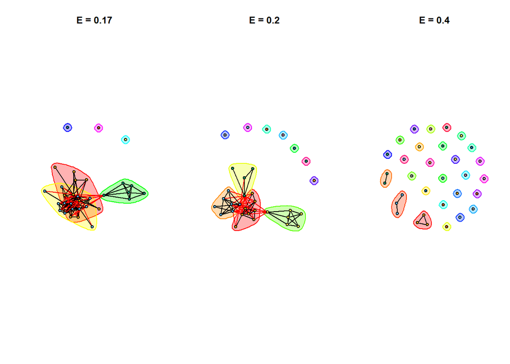

```r
par(mfrow = c(1,3))
crt_graph= cluster_fast_greedy(graph)
plot(crt_graph, graph, vertex.label=NA, vertex.size=6, main= "E = 0.17")

crt_graph1= cluster_fast_greedy(graph1)
plot(crt_graph1, graph1, vertex.label=NA, vertex.size=6, main= "E = 0.2")

crt_graph2= cluster_fast_greedy(graph2)
plot(crt_graph2, graph2, vertex.label=NA, vertex.size=6, main= "E = 0.4")
```

# marginal correlation graph based on distance covariance

Here, we perform a distance covariance test using the package ‘energy’. We calculate the p value and save it on a matrix.

```r
require('energy')
c_p = matrix(data = NA, ncol = 32, nrow = 32)
for (i in 1:32){
  for (j in 1:32){
    c_p[i,j] <- dcov.test(s[,i], s[,j], R = 200, index = 0.001)$p.value
  }
}
```

We show the dependence between stocks without Bonferroni correction.

$alpha = 0.05$

```r
stock_names1 <- colnames(s)
rownames(c_p) <- colnames(s)
colnames(c_p) <- colnames(s)

a = 0.05

#create empty graph with stocks as nodes
g <- make_empty_graph(directed = F) +
  vertices(stock_names)

#without Bonferroni correction
for (i in 1:32){
  for(j in 1:32){
    if(c_p[stock_names[i], stock_names[j]] <= a){
      if(stock_names[i] != stock_names[j]){
        g <- g + edge(stock_names[i], stock_names[j])
      }
    }
  }
}

#assign different color for each GICS
for (i in 1:length(stock_names)){
  for(j in 1:length(XX[,1])){
    if(XX$symbol[j] == stock_names[i]){
      if(XX$gics[j] == "Information Technology"){
        V(g)[i]$color = "green"
        V(g)[i]$gics = "IT"
      }else if(XX$gics[j] == 'Utilities'){
        V(g)[i]$color = 'yellow'
        V(g)[i]$gics = "UT"
      }else if(XX$gics[j] == 'Financials'){
        V(g)[i]$color = 'red'
        V(g)[i]$gics = "FI"
      }else if(XX$gics[j] == 'Health Care'){
        V(g)[i]$color = 'blue'
        V(g)[i]$gics = "HC"
      }else if(XX$gics[j] == "Consumer Staples"){
        V(g)[i]$color = 'purple'
        V(g)[i]$gics = "CST"
      }else if(XX$gics[j] == 'Real Estate'){
        V(g)[i]$color = 'black'
        V(g)[i]$gics = "RE"
      }else if(XX$gics[j] == 'Energy'){
        V(g)[i]$color = 'pink'
        V(g)[i]$gics = "EN"
      }else if(XX$gics[j] == 'Communication Services'){
        V(g)[i]$color = 'gray'
        V(g)[i]$gics = "CSE"
      }else if(XX$gics[j] == 'Industrials'){
        V(g)[i]$color = 'white'
        V(g)[i]$gics = "IND"
      }else if(XX$gics[j] == 'Materials'){
        V(g)[i]$color = 'orange'
        V(g)[i]$gics = "MA"
      }else if(XX$gics[j] == 'Consumer Discretionary'){
        V(g)[i]$color = 'brown'
        V(g)[i]$gics = "CD"
      }
    }
  }
}

par(mfrow = c(1,1))

graph <- simplify(g)
V(graph)$indegree <- centr_degree(graph, mode = "in")$res

nodes <- get.data.frame(graph, what="vertices")
nodes <- data.frame(id = nodes$name, title = nodes$name, group = nodes$gics, gics = nodes$gics)
setnames(nodes, "gics", "gics")
nodes <- nodes[order(nodes$id, decreasing = F),]

edges <- get.data.frame(graph, what="edges")[1:2]

visNetwork(nodes, edges, height = "500px", width = "100%") %>%
  visOptions(selectedBy = "gics", highlightNearest = TRUE, nodesIdSelection = TRUE)%>%
  visPhysics(stabilization = F)%>%
  visEdges(arrows  = "to")
```

[interactive chart not shown]

- As it can be seen from the graph, we observe dependencies between stocks, although this dependency isn’t dependept on GICS sector.

We show the dependence between stocks with Bonferroni correction.

```r
stock_names1 <- colnames(s)
rownames(c_p) <- colnames(s)
colnames(c_p) <- colnames(s)

a = 0.05
m = length(c_p)
am = a/m

#create empty graph with stocks as nodes
g <- make_empty_graph(directed = F) +
  vertices(stock_names[1:32])

#interaction between all stocks
#with Bonferroni correction
for (i in 1:32){
  for(j in 1:32){
    if(c_p[stock_names[i], stock_names[j]] <= am){
      if(stock_names[i] != stock_names[j]){
        g <- g + edge(stock_names[i], stock_names[j])
      }
    }
  }
}

#assign different color for each GICS
for (i in 1:length(stock_names)){
  for(j in 1:length(XX[,1])){
    if(XX$symbol[j] == stock_names[i]){
      if(XX$gics[j] == "Information Technology"){
        V(g)[i]$color = "green"
        V(g)[i]$gics = "IT"
      }else if(XX$gics[j] == 'Utilities'){
        V(g)[i]$color = 'yellow'
        V(g)[i]$gics = "UT"
      }else if(XX$gics[j] == 'Financials'){
        V(g)[i]$color = 'red'
        V(g)[i]$gics = "FI"
      }else if(XX$gics[j] == 'Health Care'){
        V(g)[i]$color = 'blue'
        V(g)[i]$gics = "HC"
      }else if(XX$gics[j] == "Consumer Staples"){
        V(g)[i]$color = 'purple'
        V(g)[i]$gics = "CST"
      }else if(XX$gics[j] == 'Real Estate'){
        V(g)[i]$color = 'black'
        V(g)[i]$gics = "RE"
      }else if(XX$gics[j] == 'Energy'){
        V(g)[i]$color = 'pink'
        V(g)[i]$gics = "EN"
      }else if(XX$gics[j] == 'Communication Services'){
        V(g)[i]$color = 'gray'
        V(g)[i]$gics = "CSE"
      }else if(XX$gics[j] == 'Industrials'){
        V(g)[i]$color = 'white'
        V(g)[i]$gics = "IND"
      }else if(XX$gics[j] == 'Materials'){
        V(g)[i]$color = 'orange'
        V(g)[i]$gics = "MA"
      }else if(XX$gics[j] == 'Consumer Discretionary'){
        V(g)[i]$color = 'brown'
        V(g)[i]$gics = "CD"
      }
    }
  }
}

par(mfrow = c(1,1))
graph <- simplify(g)

V(graph)$indegree <- centr_degree(graph, mode = "in")$res

nodes <- get.data.frame(graph, what="vertices")
nodes <- data.frame(id = nodes$name, title = nodes$name, group = nodes$gics, gics = nodes$gics)
setnames(nodes, "gics", "gics")
nodes <- nodes[order(nodes$id, decreasing = F),]

edges <- get.data.frame(graph, what="edges")[1:2]

visNetwork(nodes, edges, height = "500px", width = "100%") %>%
  visOptions(selectedBy = "gics", highlightNearest = TRUE, nodesIdSelection = TRUE)%>%
  visPhysics(stabilization = F)%>%
  visEdges(arrows  = "to")
```

[interactive chart not shown]

* As it can be seen from the graph, when we perform the hypothesis test with Bonferroni correction we don’t observe any dependency between stocks.

## Repeating the same analysis for time frame between 2013 - 2018

```r
library(corrplot)
library(igraph)
library(visNetwork)
library(data.table)
require(tseries, quietly = TRUE)
```

```r
#stock_names contains list of stock names of the randomly picked companies
stock_names = XX$symbol
#get historical data for each stock from 2003-01-01 to 2008-01-01 using get.hist.quote() from Yahoo, calculate closing price and save in a matrix vv
temp_sym = stock_names[1]
temp <- suppressWarnings( get.hist.quote(instrument=temp_sym, start="2013-01-01", end="2018-01-01", quote= c("Open","Close"), provider="yahoo", drop=TRUE) )
```

```
## time series starts 2013-01-02
## time series ends   2017-12-29
```

```r
vv =matrix(data=NA,ncol=length(temp)/2, nrow=length(XX[,1]))
for (j in 1:length(XX[,1])){
  b <- suppressWarnings( get.hist.quote(instrument=stock_names[j], start="2013-01-01", end="2018-01-01", quote= c("Open","Close"), provider="yahoo", drop=TRUE) )
  for (i in 2:length(b$Close))  {
    vv[j,i-1] = function_1(i)
  }
}
```

[output not shown]

[output cut: 9 more lines]

[output not shown]

```r
#transpose our matrix: features = stocks
stock_data = t(vv)
colnames(stock_data) = stock_names
```

#### Correlation between stocks

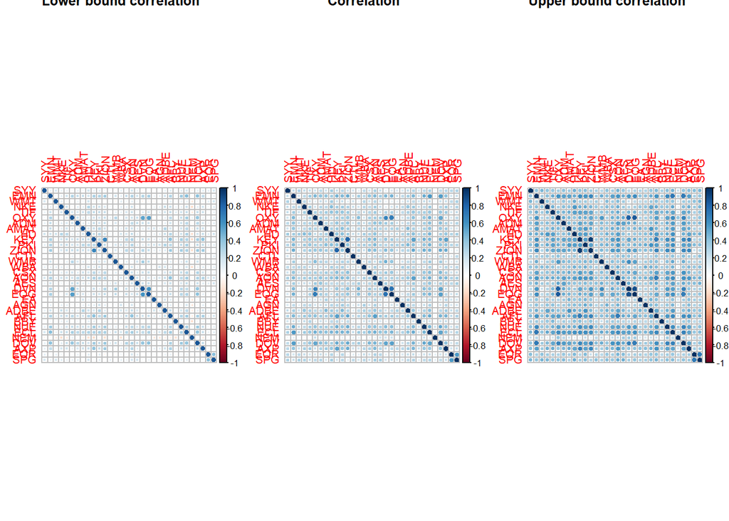

```r
#calculate correlation
s <- stock_data[1:1257,]
correlation = cor(s)

#Bootstraping 1000 times
B = 1000
#length of our value(number of closing prices for a stock)
n = length(s[,1])
bootstrap_step = function(){
  #Sample/Pick one trading day at random n times with replacement
  idx = sample(n, replace = T)
  bsamp = s[idx,]
  #calculate correlation for our sampled data
  c_bsamp = cor(bsamp)
  #Perform confidence test for the bootstrap sample
  btheta = sqrt(n) * max(abs(c_bsamp - correlation))
  return(btheta)
}

#b_sample is a list that contains B confidence test of our correlation
b_sample = replicate(B, bootstrap_step())

#Calculate t for 95% confidence
t_alpha = quantile(b_sample, 0.95)

#calculate upper bound and lower bound of our correlation
conf_int_alpha_low = correlation - t_alpha/sqrt(n)
conf_int_alpha_up = correlation + t_alpha/sqrt(n)

#When performing confidence interval some values may be out of the range of [-1,1]
#conf_int_alpha_up_adj contains values with in the range of [-1,1]
conf_int_alpha_up_adj = matrix(NA, dim(conf_int_alpha_up)[1], dim(conf_int_alpha_up)[2])

rownames(conf_int_alpha_up_adj) = rownames(conf_int_alpha_up)
colnames(conf_int_alpha_up_adj) = colnames(conf_int_alpha_up)

#Fix values out of the range of [-1,1]
for (i in 1:dim(conf_int_alpha_up)[1]){
  for (j in 1:dim(conf_int_alpha_up)[2]){
    conf_int_alpha_up_adj[i,j] = min(max(conf_int_alpha_up[i,j], -1), 1)
  }
}

par(mfrow = c(1,3))

#plot correlations
corrplot(conf_int_alpha_low, method = 'circle', main="Lower bound correlation")
corrplot(correlation, method = 'circle', main = "Correlation")
corrplot(conf_int_alpha_up_adj, method = 'circle', main = "Upper bound correlation")
```

```r
g <- make_empty_graph(directed = F) +
  vertices(stock_names)
g1 <- make_empty_graph(directed = F) +
  vertices(stock_names)
g2 <- make_empty_graph(directed = F) +
  vertices(stock_names)

eps = 0.17
eps1 = 0.2
eps2 = 0.4


for (i in 1:32){
  for(j in 1:32){
    if(  abs( conf_int_alpha_low[stock_names[i], stock_names[j]] ) >= eps){
      if(stock_names[i] != stock_names[j]){
        g <- g + edge(stock_names[i], stock_names[j])
      }
    }
  }
}

for (i in 1:32){
  for(j in 1:32){
    if(  abs( conf_int_alpha_low[stock_names[i], stock_names[j]] ) >= eps1){
      if(stock_names[i] != stock_names[j]){
       g1 <- g1 + edge(stock_names[i], stock_names[j])
      }
    }
  }
}

for (i in 1:32){
  for(j in 1:32){
    if(  abs( conf_int_alpha_low[stock_names[i], stock_names[j]] ) >= eps2){
      if(stock_names[i] != stock_names[j]){
        g2 <- g2 + edge(stock_names[i], stock_names[j])
      }
    }
  }
}


#assign different color for each GICS
for (i in 1:length(stock_names)){
  for(j in 1:length(XX[,1])){
    if(XX$symbol[j] == stock_names[i]){
      if(XX$gics[j] == "Information Technology"){
        V(g)[i]$color = "green"
        V(g)[i]$gics = "IT"
      }else if(XX$gics[j] == 'Utilities'){
        V(g)[i]$color = 'yellow'
        V(g)[i]$gics = "UT"
      }else if(XX$gics[j] == 'Financials'){
        V(g)[i]$color = 'red'
        V(g)[i]$gics = "FI"
      }else if(XX$gics[j] == 'Health Care'){
        V(g)[i]$color = 'blue'
        V(g)[i]$gics = "HC"
      }else if(XX$gics[j] == "Consumer Staples"){
        V(g)[i]$color = 'purple'
        V(g)[i]$gics = "CST"
      }else if(XX$gics[j] == 'Real Estate'){
        V(g)[i]$color = 'black'
        V(g)[i]$gics = "RE"
      }else if(XX$gics[j] == 'Energy'){
        V(g)[i]$color = 'pink'
        V(g)[i]$gics = "EN"
      }else if(XX$gics[j] == 'Communication Services'){
        V(g)[i]$color = 'gray'
        V(g)[i]$gics = "CSE"
      }else if(XX$gics[j] == 'Industrials'){
        V(g)[i]$color = 'white'
        V(g)[i]$gics = "IND"
      }else if(XX$gics[j] == 'Materials'){
        V(g)[i]$color = 'orange'
        V(g)[i]$gics = "MA"
      }else if(XX$gics[j] == 'Consumer Discretionary'){
        V(g)[i]$color = 'brown'
        V(g)[i]$gics = "CD"
      }
    }
  }
}

for (i in 1:length(stock_names)){
  for(j in 1:length(XX[,1])){
    if(XX$symbol[j] == stock_names[i]){
      if(XX$gics[j] == "Information Technology"){
        V(g1)[i]$color = "green"
        V(g1)[i]$gics = "IT"
      }else if(XX$gics[j] == 'Utilities'){
        V(g1)[i]$color = 'yellow'
        V(g1)[i]$gics = "UT"
      }else if(XX$gics[j] == 'Financials'){
        V(g1)[i]$color = 'red'
        V(g1)[i]$gics = "FI"
      }else if(XX$gics[j] == 'Health Care'){
        V(g1)[i]$color = 'blue'
        V(g1)[i]$gics = "HC"
      }else if(XX$gics[j] == "Consumer Staples"){
        V(g1)[i]$color = 'purple'
        V(g1)[i]$gics = "CST"
      }else if(XX$gics[j] == 'Real Estate'){
        V(g1)[i]$color = 'black'
        V(g1)[i]$gics = "RE"
      }else if(XX$gics[j] == 'Energy'){
        V(g1)[i]$color = 'pink'
        V(g1)[i]$gics = "EN"
      }else if(XX$gics[j] == 'Communication Services'){
        V(g1)[i]$color = 'gray'
        V(g1)[i]$gics = "CSE"
      }else if(XX$gics[j] == 'Industrials'){
        V(g1)[i]$color = 'white'
        V(g1)[i]$gics = "IND"
      }else if(XX$gics[j] == 'Materials'){
        V(g1)[i]$color = 'orange'
        V(g1)[i]$gics = "MA"
      }else if(XX$gics[j] == 'Consumer Discretionary'){
        V(g1)[i]$color = 'brown'
        V(g1)[i]$gics = "CD"
      }
    }
  }
}

for (i in 1:length(stock_names)){
  for(j in 1:length(XX[,1])){
    if(XX$symbol[j] == stock_names[i]){
      if(XX$gics[j] == "Information Technology"){
        V(g2)[i]$color = "green"
        V(g2)[i]$gics = "IT"
      }else if(XX$gics[j] == 'Utilities'){
        V(g2)[i]$color = 'yellow'
        V(g2)[i]$gics = "UT"
      }else if(XX$gics[j] == 'Financials'){
        V(g2)[i]$color = 'red'
        V(g2)[i]$gics = "FI"
      }else if(XX$gics[j] == 'Health Care'){
        V(g2)[i]$color = 'blue'
        V(g2)[i]$gics = "HC"
      }else if(XX$gics[j] == "Consumer Staples"){
        V(g2)[i]$color = 'purple'
        V(g2)[i]$gics = "CST"
      }else if(XX$gics[j] == 'Real Estate'){
        V(g2)[i]$color = 'black'
        V(g2)[i]$gics = "RE"
      }else if(XX$gics[j] == 'Energy'){
        V(g2)[i]$color = 'pink'
        V(g2)[i]$gics = "EN"
      }else if(XX$gics[j] == 'Communication Services'){
        V(g2)[i]$color = 'gray'
        V(g2)[i]$gics = "CSE"
      }else if(XX$gics[j] == 'Industrials'){
        V(g2)[i]$color = 'white'
        V(g2)[i]$gics = "IND"
      }else if(XX$gics[j] == 'Materials'){
        V(g2)[i]$color = 'orange'
        V(g2)[i]$gics = "MA"
      }else if(XX$gics[j] == 'Consumer Discretionary'){
        V(g2)[i]$color = 'brown'
        V(g2)[i]$gics = "CD"
      }
    }
  }

}

#graph with eps 0.17
graph <- simplify(g)

V(graph)$indegree <- centr_degree(graph, mode = "in")$res

nodes <- get.data.frame(graph, what="vertices")
nodes <- data.frame(id = nodes$name, title = nodes$name, group = nodes$gics, gics = nodes$gics)
setnames(nodes, "gics", "gics")
nodes <- nodes[order(nodes$id, decreasing = F),]

edges <- get.data.frame(graph, what="edges")[1:2]

visNetwork(nodes, edges, height = "500px", width = "100%") %>%
  visOptions(selectedBy = "gics", highlightNearest = TRUE, nodesIdSelection = TRUE)%>%
  visPhysics(stabilization = F)%>%
  visEdges(arrows  = "to")
```

[interactive chart not shown]

```r
#graph with eps 0.2
graph1 <- simplify(g1)

V(graph1)$indegree <- centr_degree(graph1, mode = "in")$res

nodes1 <- get.data.frame(graph1, what="vertices")
nodes1 <- data.frame(id = nodes1$name, title = nodes1$name, group = nodes1$gics, gics = nodes1$gics)
setnames(nodes1, "gics", "gics")
nodes1 <- nodes1[order(nodes1$id, decreasing = F),]

edges1 <- get.data.frame(graph1, what="edges")[1:2]

visNetwork(nodes1, edges1, height = "500px", width = "100%") %>%
  visOptions(selectedBy = "gics", highlightNearest = TRUE, nodesIdSelection = TRUE)%>%
  visPhysics(stabilization = F)%>%
  visEdges(arrows  = "to")
```

[interactive chart not shown]

```r
#graph with eps 0.2
graph2 <- simplify(g2)

V(graph2)$indegree <- centr_degree(graph2, mode = "in")$res

nodes2 <- get.data.frame(graph2, what="vertices")
nodes2 <- data.frame(id = nodes2$name, title = nodes2$name, group = nodes2$gics, gics = nodes2$gics)
setnames(nodes2, "gics", "gics")
nodes2 <- nodes2[order(nodes2$id, decreasing = F),]

edges2 <- get.data.frame(graph2, what="edges")[1:2]

visNetwork(nodes2, edges2, height = "500px", width = "100%") %>%
  visOptions(selectedBy = "gics", highlightNearest = TRUE, nodesIdSelection = TRUE)%>%
  visPhysics(stabilization = F)%>%
  visEdges(arrows  = "to")
```

[interactive chart not shown]

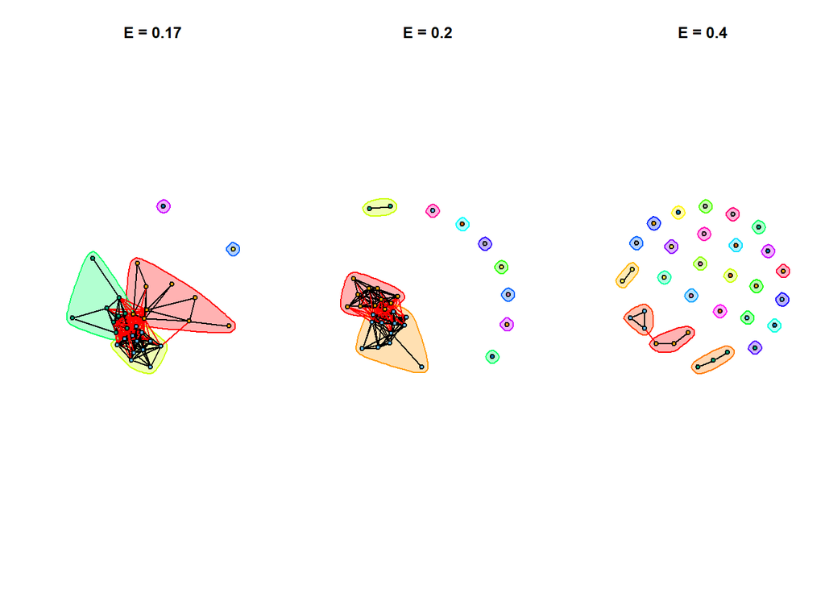

```r
par(mfrow = c(1,3))
crt_graph= cluster_fast_greedy(graph)
plot(crt_graph, graph, vertex.label=NA, vertex.size=6, main= "E = 0.17")

crt_graph1= cluster_fast_greedy(graph1)
plot(crt_graph1, graph1, vertex.label=NA, vertex.size=6, main= "E = 0.2")

crt_graph2= cluster_fast_greedy(graph2)
plot(crt_graph2, graph2, vertex.label=NA, vertex.size=6, main= "E = 0.4")
```

#### Distance Covariance

```r
require('energy')
c_p = matrix(data = NA, ncol = 32, nrow = 32)
for (i in 1:32){
  for (j in 1:32){
    c_p[i,j] <- dcov.test(s[,i], s[,j], R = 200, index = 0.001)$p.value
  }
}

stock_names1 <- colnames(s)
rownames(c_p) <- colnames(s)
colnames(c_p) <- colnames(s)

a = 0.05

#create empty graph with stocks as nodes
g <- make_empty_graph(directed = F) +
  vertices(stock_names)

#without Bonferroni correction
for (i in 1:32){
  for(j in 1:32){
    if(c_p[stock_names[i], stock_names[j]] <= a){
      if(stock_names[i] != stock_names[j]){
        g <- g + edge(stock_names[i], stock_names[j])
      }
    }
  }
}

#assign different color for each GICS
for (i in 1:length(stock_names)){
  for(j in 1:length(XX[,1])){
    if(XX$symbol[j] == stock_names[i]){
      if(XX$gics[j] == "Information Technology"){
        V(g)[i]$color = "green"
        V(g)[i]$gics = "IT"
      }else if(XX$gics[j] == 'Utilities'){
        V(g)[i]$color = 'yellow'
        V(g)[i]$gics = "UT"
      }else if(XX$gics[j] == 'Financials'){
        V(g)[i]$color = 'red'
        V(g)[i]$gics = "FI"
      }else if(XX$gics[j] == 'Health Care'){
        V(g)[i]$color = 'blue'
        V(g)[i]$gics = "HC"
      }else if(XX$gics[j] == "Consumer Staples"){
        V(g)[i]$color = 'purple'
        V(g)[i]$gics = "CST"
      }else if(XX$gics[j] == 'Real Estate'){
        V(g)[i]$color = 'black'
        V(g)[i]$gics = "RE"
      }else if(XX$gics[j] == 'Energy'){
        V(g)[i]$color = 'pink'
        V(g)[i]$gics = "EN"
      }else if(XX$gics[j] == 'Communication Services'){
        V(g)[i]$color = 'gray'
        V(g)[i]$gics = "CSE"
      }else if(XX$gics[j] == 'Industrials'){
        V(g)[i]$color = 'white'
        V(g)[i]$gics = "IND"
      }else if(XX$gics[j] == 'Materials'){
        V(g)[i]$color = 'orange'
        V(g)[i]$gics = "MA"
      }else if(XX$gics[j] == 'Consumer Discretionary'){
        V(g)[i]$color = 'brown'
        V(g)[i]$gics = "CD"
      }
    }
  }
}

par(mfrow = c(1,1))

graph <- simplify(g)
V(graph)$indegree <- centr_degree(graph, mode = "in")$res

nodes <- get.data.frame(graph, what="vertices")
nodes <- data.frame(id = nodes$name, title = nodes$name, group = nodes$gics, gics = nodes$gics)
setnames(nodes, "gics", "gics")
nodes <- nodes[order(nodes$id, decreasing = F),]

edges <- get.data.frame(graph, what="edges")[1:2]

visNetwork(nodes, edges, height = "500px", width = "100%") %>%
  visOptions(selectedBy = "gics", highlightNearest = TRUE, nodesIdSelection = TRUE)%>%
  visPhysics(stabilization = F)%>%
  visEdges(arrows  = "to")
```

[interactive chart not shown]

```r
stock_names1 <- colnames(s)
rownames(c_p) <- colnames(s)
colnames(c_p) <- colnames(s)

a = 0.05
m = length(c_p)
am = a/m

#create empty graph with stocks as nodes
g <- make_empty_graph(directed = F) +
  vertices(stock_names[1:32])

#interaction between all stocks
#with Bonferroni correction
for (i in 1:32){
  for(j in 1:32){
    if(c_p[stock_names[i], stock_names[j]] <= am){
      if(stock_names[i] != stock_names[j]){
        g <- g + edge(stock_names[i], stock_names[j])
      }
    }
  }
}

#assign different color for each GICS
for (i in 1:length(stock_names)){
  for(j in 1:length(XX[,1])){
    if(XX$symbol[j] == stock_names[i]){
      if(XX$gics[j] == "Information Technology"){
        V(g)[i]$color = "green"
        V(g)[i]$gics = "IT"
      }else if(XX$gics[j] == 'Utilities'){
        V(g)[i]$color = 'yellow'
        V(g)[i]$gics = "UT"
      }else if(XX$gics[j] == 'Financials'){
        V(g)[i]$color = 'red'
        V(g)[i]$gics = "FI"
      }else if(XX$gics[j] == 'Health Care'){
        V(g)[i]$color = 'blue'
        V(g)[i]$gics = "HC"
      }else if(XX$gics[j] == "Consumer Staples"){
        V(g)[i]$color = 'purple'
        V(g)[i]$gics = "CST"
      }else if(XX$gics[j] == 'Real Estate'){
        V(g)[i]$color = 'black'
        V(g)[i]$gics = "RE"
      }else if(XX$gics[j] == 'Energy'){
        V(g)[i]$color = 'pink'
        V(g)[i]$gics = "EN"
      }else if(XX$gics[j] == 'Communication Services'){
        V(g)[i]$color = 'gray'
        V(g)[i]$gics = "CSE"
      }else if(XX$gics[j] == 'Industrials'){
        V(g)[i]$color = 'white'
        V(g)[i]$gics = "IND"
      }else if(XX$gics[j] == 'Materials'){
        V(g)[i]$color = 'orange'
        V(g)[i]$gics = "MA"
      }else if(XX$gics[j] == 'Consumer Discretionary'){
        V(g)[i]$color = 'brown'
        V(g)[i]$gics = "CD"
      }
    }
  }
}

par(mfrow = c(1,1))
graph <- simplify(g)

V(graph)$indegree <- centr_degree(graph, mode = "in")$res

nodes <- get.data.frame(graph, what="vertices")
nodes <- data.frame(id = nodes$name, title = nodes$name, group = nodes$gics, gics = nodes$gics)
setnames(nodes, "gics", "gics")
nodes <- nodes[order(nodes$id, decreasing = F),]

edges <- get.data.frame(graph, what="edges")[1:2]

visNetwork(nodes, edges, height = "500px", width = "100%") %>%
  visOptions(selectedBy = "gics", highlightNearest = TRUE, nodesIdSelection = TRUE)%>%
  visPhysics(stabilization = F)%>%
  visEdges(arrows  = "to")
```

[interactive chart not shown]

As it can be seen from the graph, there is no noteable difference between timeseries 2003-2008 and 2013-2018. Stocks from the time series 2013-2018 don’t interact more with stocks from the same GICS sector.

The same can be observed for distance covariance. Dependency betweeen stocks is observed without Bonferroni correction. With Bonferroni correction no dependency is observed.